# Prediction of the classe based on exercise results

## Loading libraries and training

Loading the necessary libraries and also genering a training and a testing set to be used

```r
library(tidyverse)
```

```r
library(ggplot2)
library(caret)
# loading the data

#training file

url<-"https://d396qusza40orc.cloudfront.net/predmachlearn/pml-training.csv"
training<-read.csv(url)

#training has 19622 records and 160 columns

url2<-"https://d396qusza40orc.cloudfront.net/predmachlearn/pml-testing.csv"
testing<-read.csv(url2)

#testing has 20 records and 160 columns
# classe is the item we are trying to predict
```

## Data cleansing

Quite a lot of NA values in the data set.Some blanks do not appear to be NA’s so we have to make them look like NA values.This is the amount of NA values

creating a data set without the classe ( in training)and problem_id column ( in testing)

```r
training_clean<-training %>% select ( -c("classe"))
classe<-training %>% select ( classe)

testing_clean<-testing %>% select ( -c("problem_id"))
problem_id<-testing %>% select ( problem_id)
```

Mutating the data sets to turn blanks in NA values

```r
training_clean <- training_clean %>%
        mutate_at(vars(colnames(.)),
                  .funs = funs(ifelse(.=="", NA, as.numeric(.))))
testing_clean <- testing_clean %>%
        mutate_at(vars(colnames(.)),
                  .funs = funs(ifelse(.=="", NA, as.numeric(.))))
# when I count the NA's this time, I get more
nacount<-sapply(training, function(x) sum(is.na(x)))
nacount
```

```
##                        X                user_name     raw_timestamp_part_1
##                        0                        0                        0
##     raw_timestamp_part_2           cvtd_timestamp               new_window
##                        0                        0                        0
##               num_window                roll_belt               pitch_belt
##                        0                        0                        0
##                 yaw_belt         total_accel_belt       kurtosis_roll_belt
##                        0                        0                        0
##      kurtosis_picth_belt        kurtosis_yaw_belt       skewness_roll_belt
##                        0                        0                        0
##     skewness_roll_belt.1        skewness_yaw_belt            max_roll_belt
##                        0                        0                    19216
##           max_picth_belt             max_yaw_belt            min_roll_belt
##                    19216                        0                    19216
##           min_pitch_belt             min_yaw_belt      amplitude_roll_belt
##                    19216                        0                    19216
##     amplitude_pitch_belt       amplitude_yaw_belt     var_total_accel_belt
##                    19216                        0                    19216
##            avg_roll_belt         stddev_roll_belt            var_roll_belt
##                    19216                    19216                    19216
##           avg_pitch_belt        stddev_pitch_belt           var_pitch_belt
##                    19216                    19216                    19216
##             avg_yaw_belt          stddev_yaw_belt             var_yaw_belt
##                    19216                    19216                    19216
##             gyros_belt_x             gyros_belt_y             gyros_belt_z
##                        0                        0                        0
##             accel_belt_x             accel_belt_y             accel_belt_z
##                        0                        0                        0
##            magnet_belt_x            magnet_belt_y            magnet_belt_z
##                        0                        0                        0
##                 roll_arm                pitch_arm                  yaw_arm
##                        0                        0                        0
##          total_accel_arm            var_accel_arm             avg_roll_arm
##                        0                    19216                    19216
##          stddev_roll_arm             var_roll_arm            avg_pitch_arm
##                    19216                    19216                    19216
##         stddev_pitch_arm            var_pitch_arm              avg_yaw_arm
##                    19216                    19216                    19216
##           stddev_yaw_arm              var_yaw_arm              gyros_arm_x
##                    19216                    19216                        0
```

[output cut: 53 more lines]

```
##                        0                        0                    19216
##         avg_roll_forearm      stddev_roll_forearm         var_roll_forearm
##                    19216                    19216                    19216
##        avg_pitch_forearm     stddev_pitch_forearm        var_pitch_forearm
##                    19216                    19216                    19216
##          avg_yaw_forearm       stddev_yaw_forearm          var_yaw_forearm
##                    19216                    19216                    19216
##          gyros_forearm_x          gyros_forearm_y          gyros_forearm_z
##                        0                        0                        0
##          accel_forearm_x          accel_forearm_y          accel_forearm_z
##                        0                        0                        0
##         magnet_forearm_x         magnet_forearm_y         magnet_forearm_z
##                        0                        0                        0
##                   classe
##                        0
```

Now getting rid of the columns containing a lot of NA

```r
training_clean<-training_clean %>%
        purrr::discard(~sum(is.na(.x))/length(.x)* 100 >=50)

testing_clean<-testing_clean %>%
        purrr::discard(~sum(is.na(.x))/length(.x)* 100 >=50)
```

Data sets with the problem_id and classe variables added back in

```r
training_clean<-cbind(training_clean,classe)
testing_clean<-cbind(testing_clean,problem_id)
```

Removing some more columns containing dates and user names. I do not wish to use those for predictions. The final training_fin sets contain the clean data minus the useless columns

```r
training_fin<-select(training_clean,-c(1:7))
testing_fin<-select(testing_clean,-c(1:7))
training_fin$classe<-as.factor(training_fin$classe)
```

## Data exploration

I decided to do a PCA analysis to see how many columns are important.I did it on the training_clean data. Here is a plot depicting how the different classes are distributed. Doesn’t say much. We do see 5 categories but they are not necessarily very separated from each other

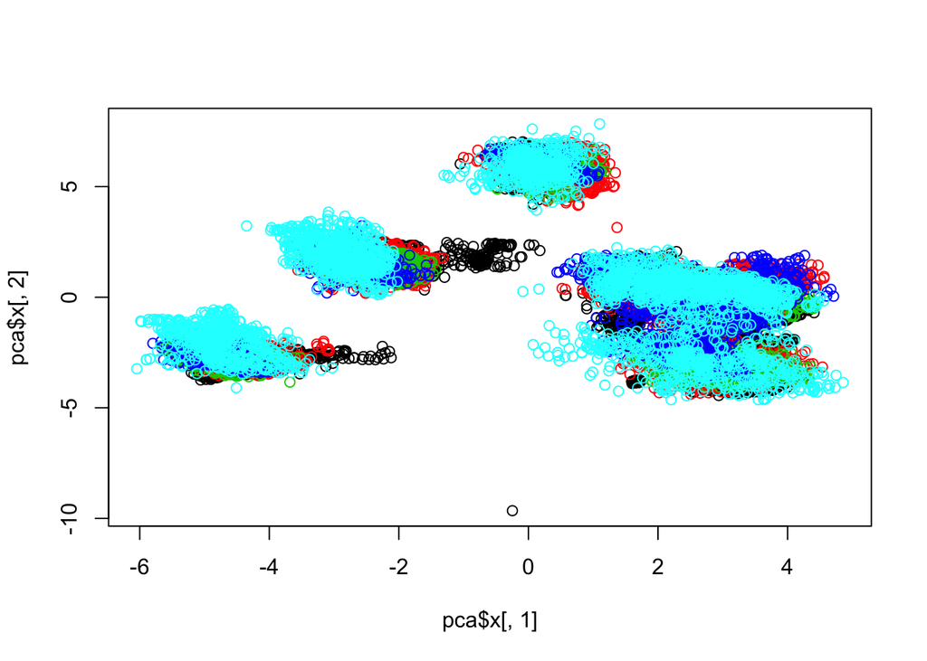

```r
training_clean<-training_clean %>% select ( -c("classe"))
pca<-prcomp(training_clean,scale=TRUE)


plot(pca$x[,1],pca$x[,2],col=training$classe)
```

When we plot how each principal component contributes to the variation then we see that PCA1 and 2 account for about 15% each, which is not a lot. This means we better use all attributes available

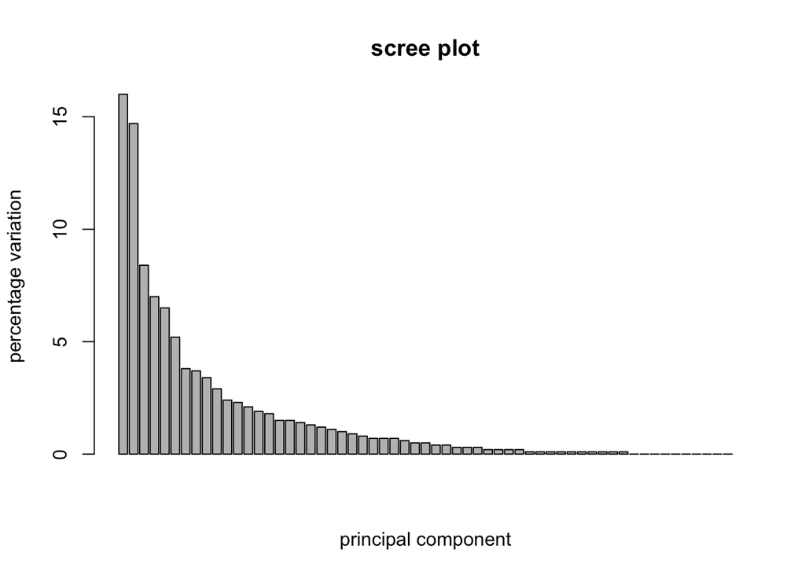

```r
pca.var<-pca$sdev^2
pca.var.per<-round(pca.var/sum(pca.var)*100,1)
barplot(pca.var.per,main="scree plot",xlab="principal component",ylab="percentage variation")
```

Here we look at the loading scores : the importance of each attribute

```r
loading_scores <- pca$rotation[,1]
move_scores <- abs(loading_scores) ## get the magnitudes
move_score_ranked <- sort(move_scores, decreasing=TRUE)
top_10_moves <- names(move_score_ranked[1:10])

##top_10_moves ## show the names of the top 10 contributors

pca$rotation[top_10_moves,1]
```

```
##         yaw_belt   cvtd_timestamp        roll_belt     accel_belt_z
##       -0.2971992        0.2935219       -0.2834617        0.2747850
## total_accel_belt      accel_arm_y     accel_belt_y      gyros_arm_z
##       -0.2653315        0.2647119       -0.2275418       -0.2260844
##     gyros_belt_y        user_name
##       -0.2102474        0.1996129
```

Better use all attributes

## Training and crossvalidation

I chose to train using 3 models : linear support vector machine, random forest and gradient boost

I trained each of the models using 10 fold cross validation repeated 3 times to consider out-of-sample errors

### cross validation

I set train control to

```r
train.control<- trainControl(method = "repeatedcv",
                              number = 10, repeats = 3)
```

and will use it in all training

### training

I fitted the 3 models using gradient boost, random forest and support vector machine respectively

```r
fit_gbm<-train(classe~.,method="gbm",data=training_fin,trControl=train.control)
fit_rf<-train(classe~.,method="rf",data=training_fin,trControl=train.control)
fit_svm_Linear <- train( classe~., data = training_fin, method = "svmLinear",
                         trControl=train.control,
                         preProcess = c("center", "scale"),
                         tuneLength = 10)
```

When looking at the results, then the random forest model wins, followed closely by the gradient boost. We’ll go for the random forest

```r
print(fit_gbm)
```

```
## Stochastic Gradient Boosting
##
## 19622 samples
##    52 predictor
##     5 classes: 'A', 'B', 'C', 'D', 'E'
##
## No pre-processing
## Resampling: Cross-Validated (10 fold, repeated 3 times)
## Summary of sample sizes: 17660, 17662, 17659, 17660, 17659, 17660, ...
## Resampling results across tuning parameters:
##
##   interaction.depth  n.trees  Accuracy   Kappa
##   1                   50      0.7532359  0.6871304
##   1                  100      0.8211534  0.7735968
##   1                  150      0.8540922  0.8153683
##   2                   50      0.8557568  0.8172330
##   2                  100      0.9081980  0.8838293
##   2                  150      0.9332716  0.9155605
##   3                   50      0.8974623  0.8701918
##   3                  100      0.9436172  0.9286568
##   3                  150      0.9636632  0.9540269
##
## Tuning parameter 'shrinkage' was held constant at a value of 0.1
##
## Tuning parameter 'n.minobsinnode' was held constant at a value of 10
## Accuracy was used to select the optimal model using the largest value.
## The final values used for the model were n.trees = 150,
##  interaction.depth = 3, shrinkage = 0.1 and n.minobsinnode = 10.
```

```r
print(fit_rf)
```

```
## Random Forest
##
## 19622 samples
##    52 predictor
##     5 classes: 'A', 'B', 'C', 'D', 'E'
##
## No pre-processing
## Resampling: Cross-Validated (10 fold, repeated 3 times)
## Summary of sample sizes: 17660, 17660, 17659, 17660, 17661, 17659, ...
## Resampling results across tuning parameters:
##
##   mtry  Accuracy   Kappa
##    2    0.9955660  0.9943911
##   27    0.9950736  0.9937684
##   52    0.9899433  0.9872773
##
## Accuracy was used to select the optimal model using the largest value.
## The final value used for the model was mtry = 2.
```

```r
print(fit_svm_Linear)
```

```
## Support Vector Machines with Linear Kernel
##
## 19622 samples
##    52 predictor
##     5 classes: 'A', 'B', 'C', 'D', 'E'
##
## Pre-processing: centered (52), scaled (52)
## Resampling: Cross-Validated (10 fold, repeated 3 times)
## Summary of sample sizes: 17661, 17660, 17659, 17659, 17661, 17661, ...
## Resampling results:
##
##   Accuracy   Kappa
##   0.7864474  0.728514
##
## Tuning parameter 'C' was held constant at a value of 1
```

the OUT-OF-SAMPE error that is to be expected for the random forest model is to be seen here :

```r
fit_rf$finalModel
```

```
##
## Call:
##  randomForest(x = x, y = y, mtry = param$mtry)
##                Type of random forest: classification
##                      Number of trees: 500
## No. of variables tried at each split: 2
##
##         OOB estimate of  error rate: 0.42%
## Confusion matrix:
##      A    B    C    D    E  class.error
## A 5578    1    0    0    1 0.0003584229
## B   12 3782    3    0    0 0.0039504872
## C    0   19 3403    0    0 0.0055523086
## D    0    0   40 3173    3 0.0133706468
## E    0    0    0    4 3603 0.0011089548
```

## Predictions

I use the random forest model to predict the testing set and will show the results associated with the problem_id numbers from the test set

```r
testing_fin<-testing_fin %>% select ( -c("problem_id"))
Pred_rf<-predict(fit_rf,testing_fin)
results<-cbind(Pred_rf,problem_id)
results
```

```
##    Pred_rf problem_id
## 1        B          1
## 2        A          2
## 3        B          3
## 4        A          4
## 5        A          5
## 6        E          6
## 7        D          7
## 8        B          8
## 9        A          9
## 10       A         10
## 11       B         11
## 12       C         12
## 13       B         13
## 14       A         14
## 15       E         15
## 16       E         16
## 17       A         17
## 18       B         18
## 19       B         19
## 20       B         20
```